# (Google Play Store)

## by (Fahad Alnuaimi)

## Investigation Overview

> This presentation will illustrate the relationships between columns in Dataset Google play store to expline the distibution fo Data and what's the observation that have been built on these relations. The Visualization of Data will show how each variable intract with other and measure the effect over the outcomes.

## Dataset Overview

> The Dataset is for Google play store which isthe main market for Android (Mobile opreating system), the Dataset contain 10841 rows and 13 columns. It has columnss aof app name, rating number, category of the app, content rating and how many got reviews and installs for each app.

## Distribution of APPS Rating

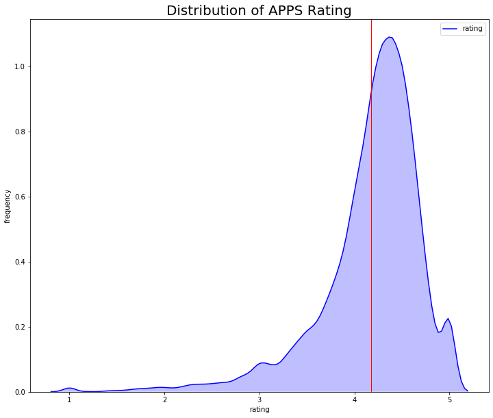

```python
# rating distibution
rcParams['figure.figsize'] = 12,10
g = sns.kdeplot(df_play_store_clean.rating, color="Blue", shade = True)
g.set_xlabel("rating")
g.set_ylabel("frequency")
plt.title('Distribution of APPS Rating',size = 20)

# drow red line for the mean
plt.axvline(df_play_store_clean.rating.mean(), color='Red', linestyle='solid', linewidth=1)
```

## Count Apps Type

> Count the type of Apps, wether this app is free or paied. By counting the apps its hsow that 92% of apps are free and 8% are paied.

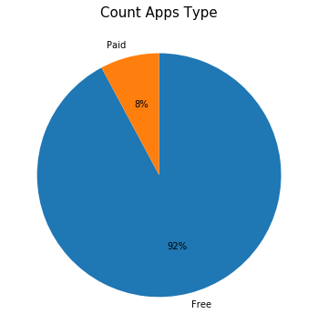

```python
# code for the pie chart seen above
plt.figure(0,figsize = (6,7))
sorted_counts = df_play_store_clean['type'].value_counts()
plt.pie(sorted_counts, labels = sorted_counts.index, startangle = 90, counterclock = False, autopct='%1.0f%%');
plt.title('Count Apps Type',color = 'Black',fontsize = 15)
plt.show;
```

## Bar Char Count Of Apps In Each Genres

> Count the main genres of apps, the plot show that tools show the highst count of apps genres, then entertaimnet, education, busness and medical. This column have taken from column genres and splitted to two categories main and sub genres and this plot of main genres.
- Tools
- Entertainment
- Education
- Business
- Medical

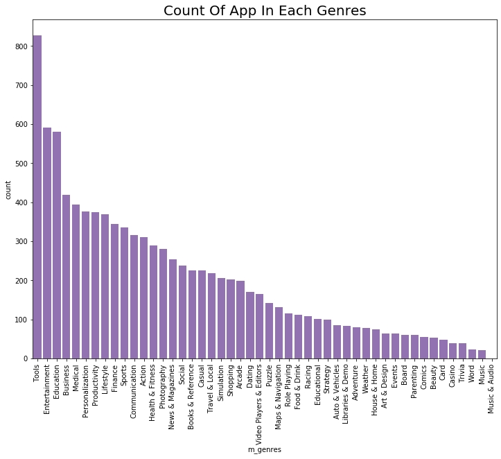

```python
#prepare value count for plot
genres_counts = df_play_store_clean['m_genres'].value_counts()
genres_order = genres_counts.index
# visulizae main category
plt.figure(figsize=(12,9))
plt.title('Count Of App In Each Genres',size = 20)
base_color = sns.color_palette()[4]
fig = sns.countplot(x=df_play_store_clean['m_genres'], color=base_color, order= genres_order)
fig.set_xticklabels(fig.get_xticklabels(), rotation=90)
plt.show(fig)
```

## Category Rating rlationship with Reviews distributeed on it

> The purpose of this visualization is to see user behavier on reviews, the four stars category has the highest reviews and most of review are bellow 10 millions

```python
px.scatter(df_play_store_clean, width=600, height=600 ,x="rating_category",y="reviews", orientation="h", title="Category Rating rlationship with Reviews distributeed on it")
```

[interactive chart not shown]

## Heatmap shows correlation of rating, reviews, size, installs, price

> The purpose of this visualization is to measure corrolation between columns, as you can see there's high correlation between reviews and installs. This correlation means that prove positive relation.

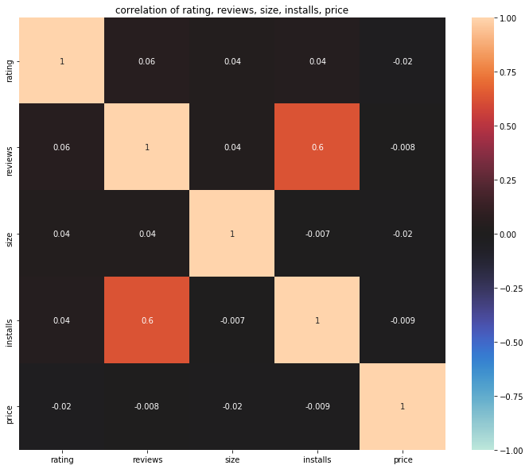

```python
aex = plt.axes()
sns.heatmap(df_play_store_clean.corr(), annot = True, fmt='.1g', vmin=-1, vmax=1, center= 0)
aex.set_title('correlation of rating, reviews, size, installs, price')
```

## Scatter Bubble show the relationship between installs and reviews in free Apps

```python
df_play_store_clean.iplot(kind='bubble', x="rating_category",y="installs",categories="type", size='reviews', xTitle='Rating Stars', yTitle='installs', title="Scatter show the relationship between installs and reviews in free Apps")
```

[interactive chart not shown]